# Attractive LLIN

### Effect of physiological and behavioral resistance

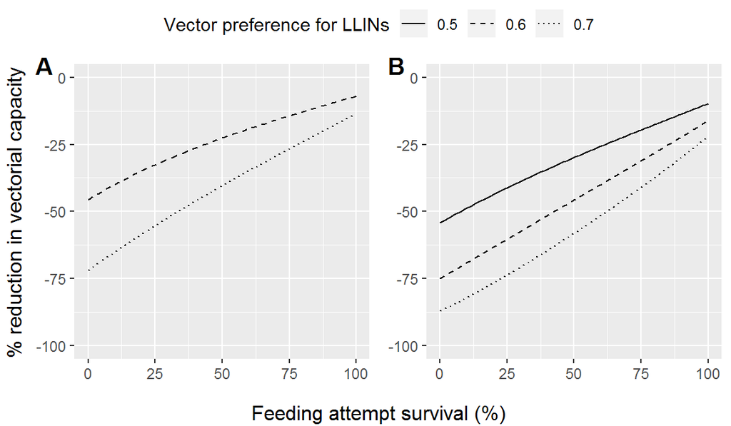

##### Figure 2: Reduction of malaria transmission induced (A) by attractive Long-lasting Insecticidal Nets (LLINs) compared to inert ones and (B) by attractive and inert LLIN compared to deterrent ones for varied levels of physiological resistance in the vector population.

###### *An attraction rate of 0.6 indicates that 60% of malaria vectors choose a human under an LLIN if presented against an unprotected human. The reference inert LLIN (panel A) has an attraction rate of 0.5 (no preference between LLIN protected or unprotected humans) and the reference deterrent LLIN (panel B) has an attraction rate of 0.36 (only 36% of the vectors choose an LLIN protected human against an unprotected human).*

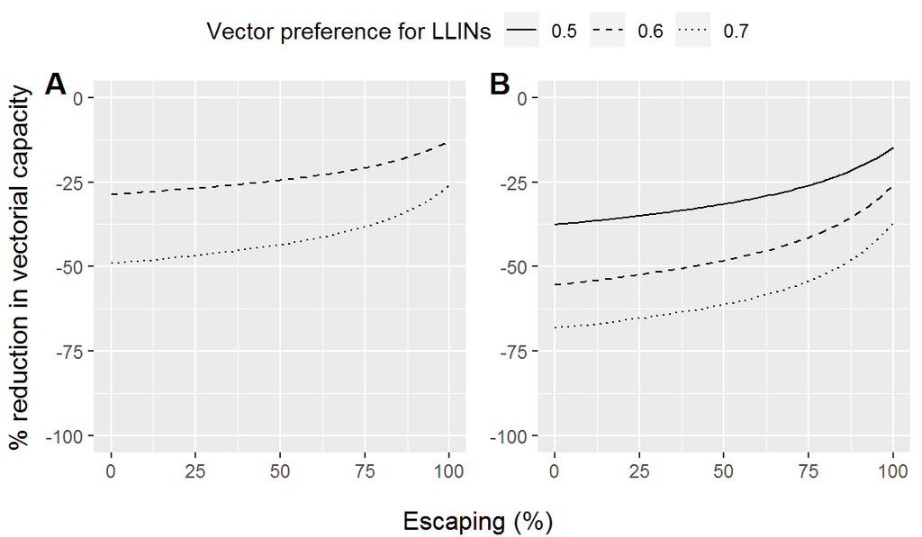